# Statistiques Descriptives

## TECHNIQUE D’OBSERVATION

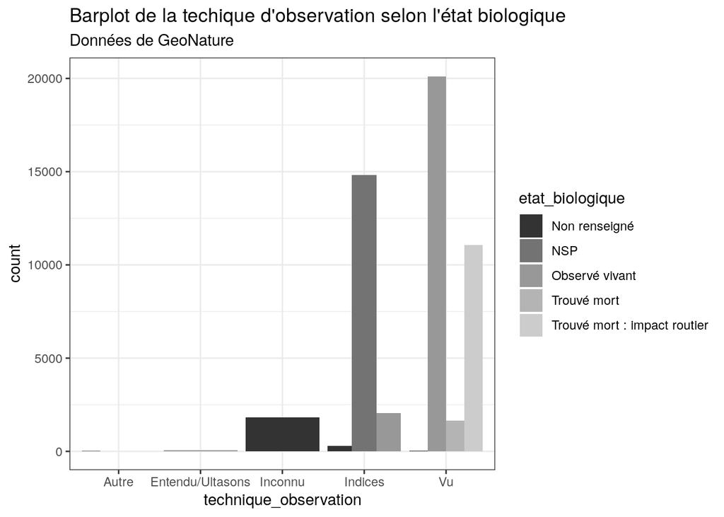

```r
ggplot(GeoN,
       aes(technique_observation,
           fill=etat_biologique)
       )+
  geom_bar(position="dodge")+
  theme_bw()+
  scale_fill_grey(start = 0.2,
                  end = 0.8,
                  na.value = "red")+
  labs(title = "Barplot de la techique d'observation selon l'état biologique",
       subtitle = "Données de GeoNature")+
  theme_bw()+
  scale_fill_grey(start = 0.2,
                  end = 0.8,
                  na.value = "red")
```

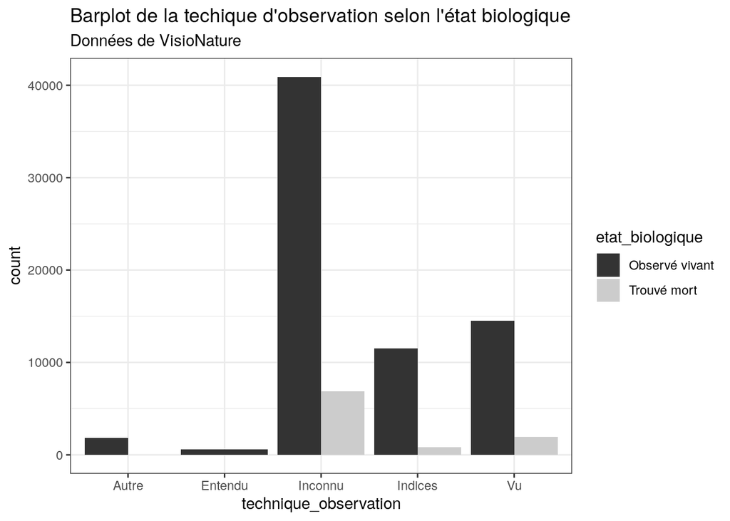

```r
ggplot(VisioN_FB,
       aes(technique_observation,
           fill=etat_biologique
           )
       )+
  geom_bar(position="dodge")+
  theme_bw()+
  scale_fill_grey(start = 0.2,
                  end = 0.8,
                  na.value = "red")+
  labs(title = "Barplot de la techique d'observation selon l'état biologique",
       subtitle = "Données de VisioNature")
```

Les données avec une technique d’obs “Inconnu” et avec un commentaire contenant des mots clefs comme des variables d’empreintes, composent la technique d’observation “Indice”. Après ce filtre, il ne reste plus que 264 dont nous avons a la fois une technique d’observation “Inconnus” et un commentaire non-vide. Ces commentaires sont assez aléatoire et beaucoup ne donnent pas d’infos supplémentaire.

Quantité d’observations GeoNature Et VisioNature

[figure not shown]

[figure not shown]

Les lapins & lièvres sont peu remarqués avec les indices comparé aux autres dans VisioNature

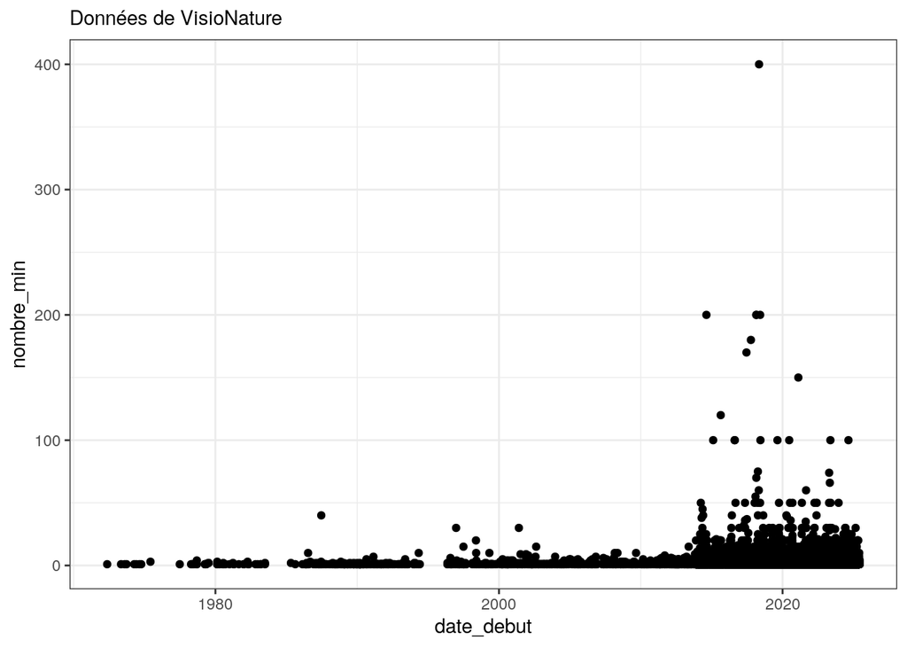

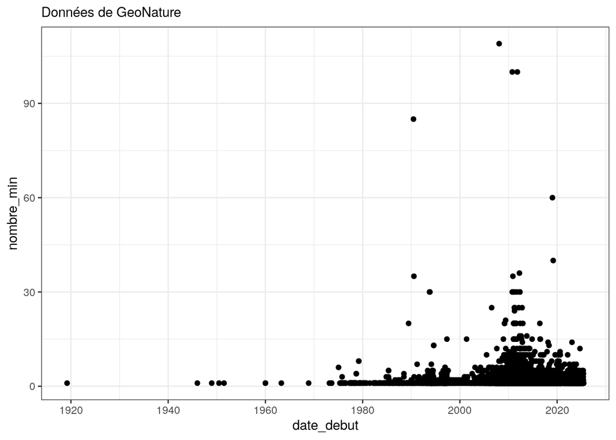

## LES DATES SELON LES ORDRES

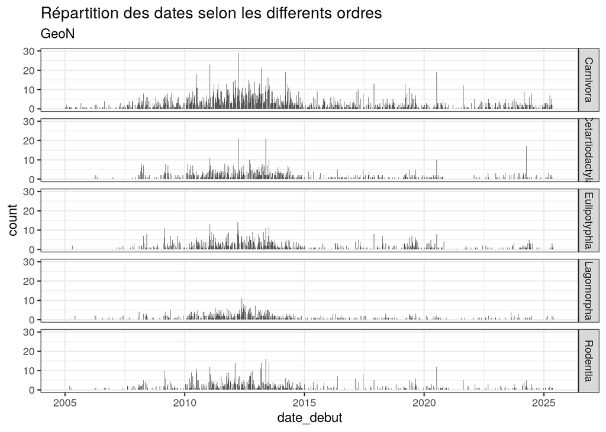

```r
GeoN%>%
  ggplot(aes(date_debut)) +
  geom_bar()+
  labs(title="Répartition des dates selon les differents ordres",
       subtitle="GeoN")+
  facet_grid(ordre ~ .)+
  ylim(0, 30)+
  theme_bw()
```

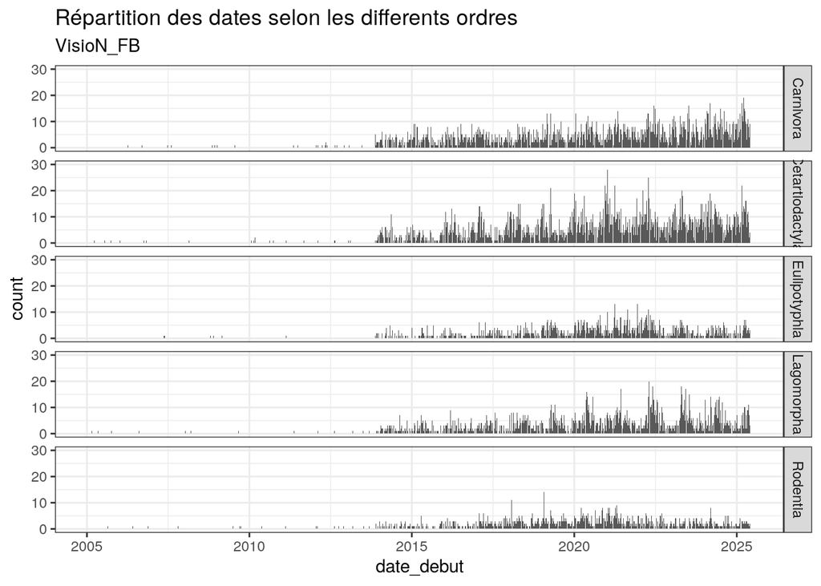

```r
VisioN_FB%>%
  ggplot(aes(date_debut))+
  geom_bar()+
  labs(title="Répartition des dates selon les differents ordres",
       subtitle="VisioN_FB")+
  facet_grid(ordre ~ .) +
  ylim(0, 30)+
  theme_bw()
```

On a des données a differentes périodes entre ces deux bases de données. Essayer de les rassembler pour savoir si ca peut compenser entre eux. (en esperant que ce soit des differences de données non pas du a un réel changement des population a ces moments là mais du a plus d’observateurs)

Calcul des correlations selon moyenne mobile?

….

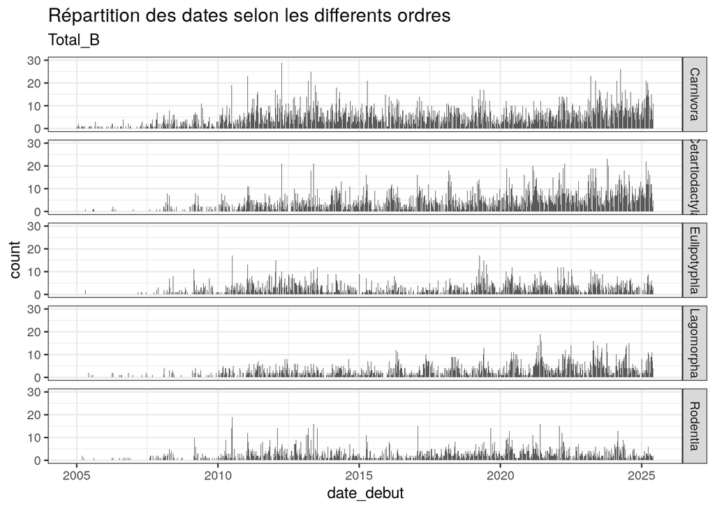

```r
Total_B%>%
  ggplot(aes(date_debut))+
  geom_bar()+
  labs(title="Répartition des dates selon les differents ordres",
       subtitle="Total_B")+
  facet_grid(ordre ~ .)+
  ylim(0, 30)+
  theme_bw()
```

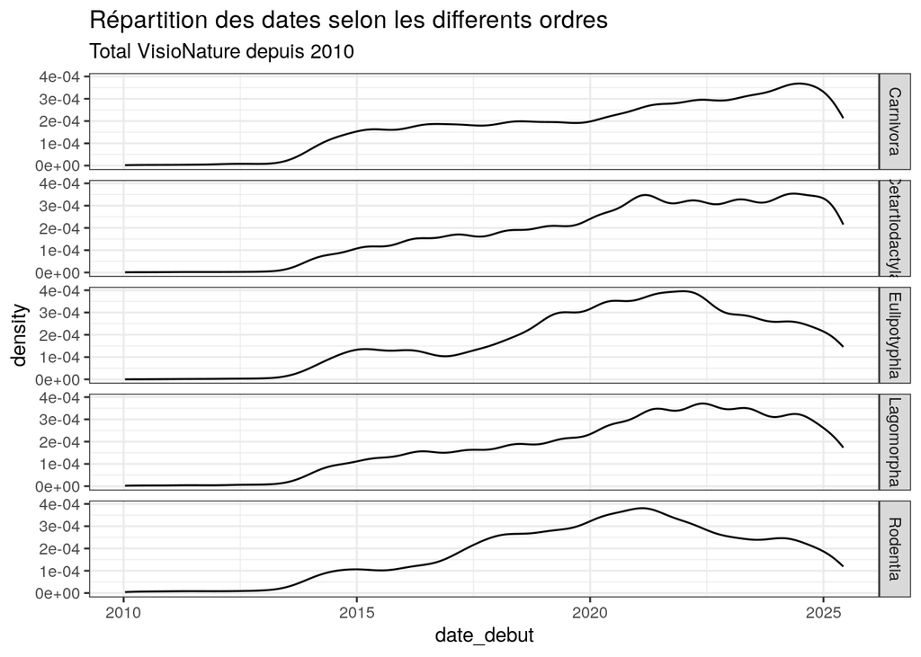

```r
VisioN_FB%>%
  filter(date_debut > as.Date("2010-01-01"))%>%
  ggplot(aes(date_debut))+
  labs(title="Répartition des dates selon les differents ordres",
       subtitle="Total VisioNature depuis 2010")+
  facet_grid(ordre ~ .)+
  theme_bw()+
  geom_line(stat="density")
```

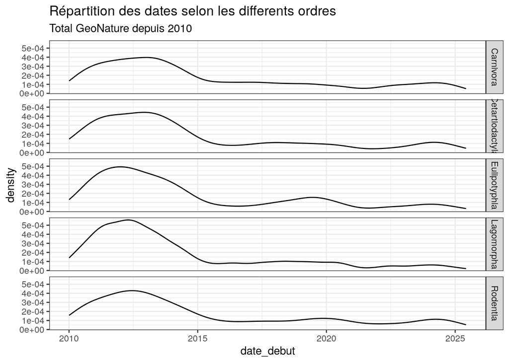

```r
GeoN%>%
  filter(date_debut > as.Date("2010-01-01"))%>%
  ggplot(aes(date_debut))+
  labs(title="Répartition des dates selon les differents ordres",
       subtitle="Total GeoNature depuis 2010")+
  facet_grid(ordre ~ .)+
  theme_bw()+
  geom_line(stat="density")
```

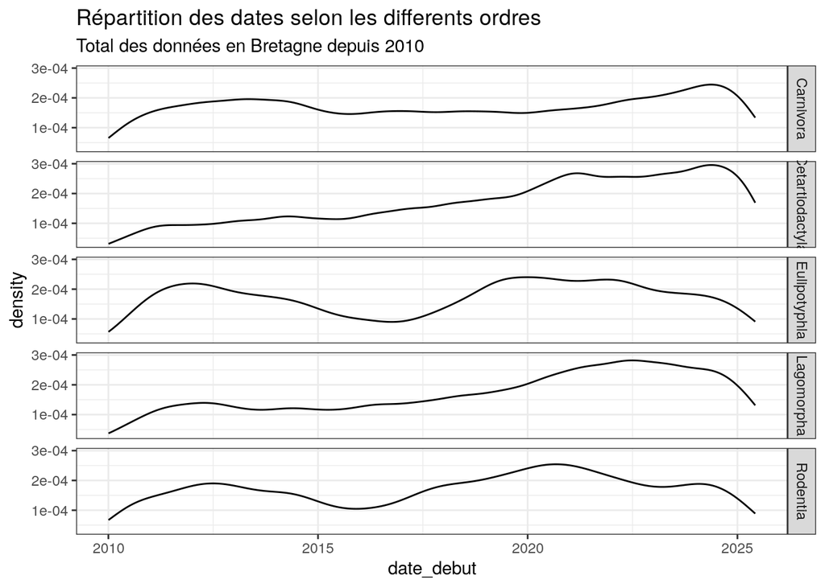

```r
Total_B%>%
  filter(date_debut > as.Date("2010-01-01"))%>%
  ggplot(aes(date_debut))+
  labs(title="Répartition des dates selon les differents ordres",
       subtitle="Total des données en Bretagne depuis 2010")+
  facet_grid(ordre ~ .)+
  theme_bw()+
  geom_line(stat="density")
```

A mon gout couper avant 2010 pour eviter de trop changer les données Et voir par rapport aux observateurs ce que ca donne Ie + d’observateurs => plus d’observations car ils les voyaient sans les inscrire avant? Créer colonne observations = somme des observations Si une observation de 2 lapins => 2 observations.

## REP CARTOGRAPHIQUE DES DONNEES

```r
# Carte bretagne
setwd("~/work/AnalyseDonneesOpportunisteGMB/donnees/DepartementsOuest")
carte_bretagne <- st_read("LIM_ADM_DepartementsOuest.shp")
```

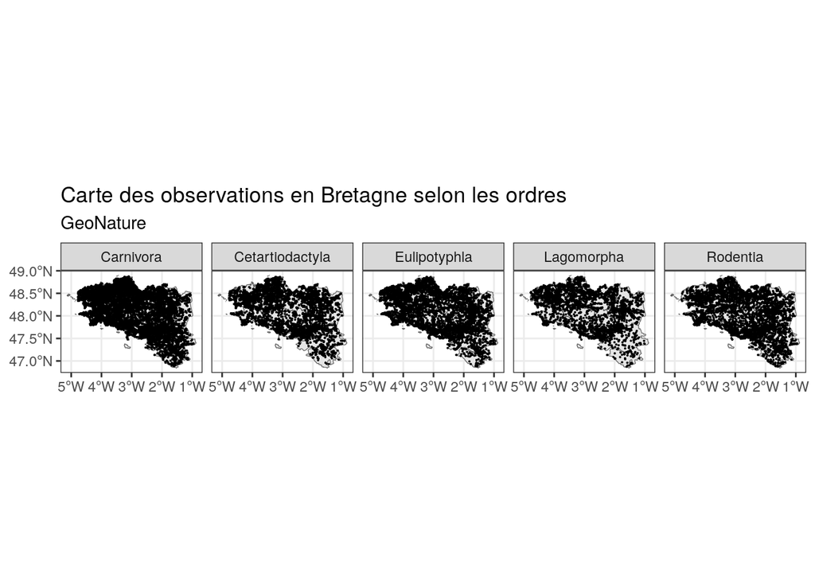

```r
carte_bretagne <- st_set_crs(carte_bretagne, 2154)
carte_bretagne <- st_transform(carte_bretagne, 4326)

# Données geographique
Geo_VisioN <- VisioN_FB %>%
  filter(date_debut > as.Date("2010-01-01")) %>%
  dplyr::select(x_centroid_4326,
                y_centroid_4326,
                ordre,
                date_debut) %>%
  sf::st_as_sf(coords = c("x_centroid_4326", "y_centroid_4326"),
               crs = sf::st_crs(4326))

Geo_GeoN <- GeoN %>%
  filter(date_debut > as.Date("2010-01-01")) %>%
  dplyr::select(x_centroid_4326,
                y_centroid_4326,
                ordre,
                date_debut) %>%
  sf::st_as_sf(coords = c("x_centroid_4326", "y_centroid_4326"),
               crs = sf::st_crs(4326))

ggplot() +
  geom_sf(data = carte_bretagne) +
  labs(title = "Carte des observations en Bretagne selon les ordres",
       subtitle = "GeoNature") +
  geom_sf(data = Geo_GeoN, size=0.01) +
  theme_bw() + facet_grid(. ~ ordre)
```

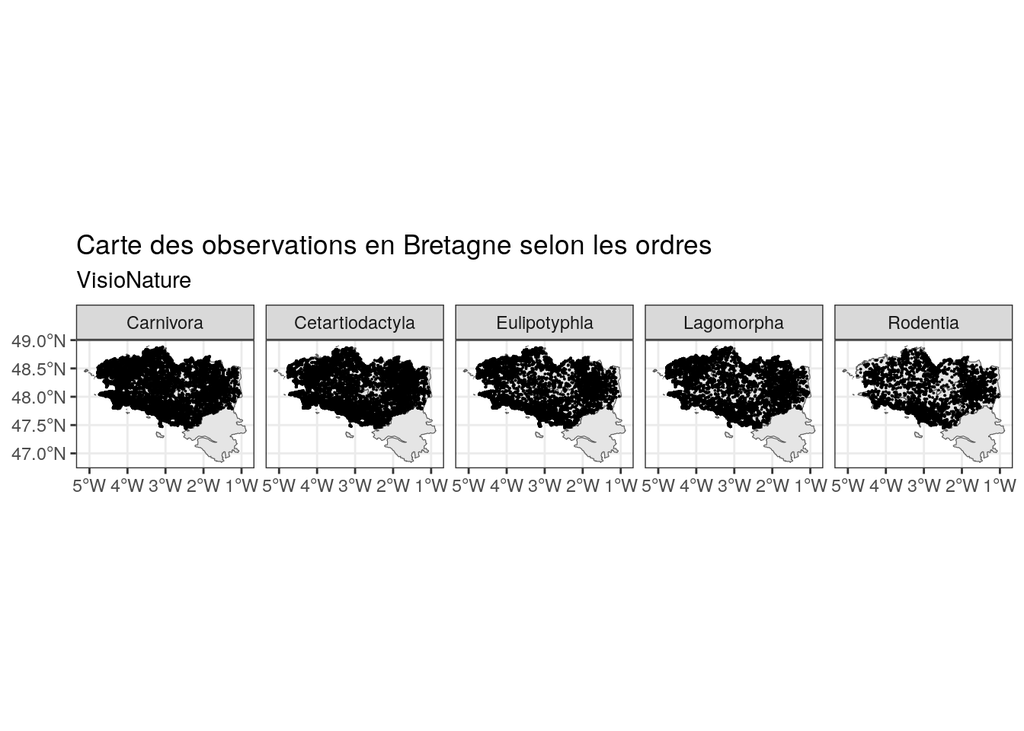

```r
ggplot() +
  geom_sf(data = carte_bretagne) +
  labs(title = "Carte des observations en Bretagne selon les ordres",
       subtitle = "VisioNature") +
  geom_sf(data = Geo_VisioN, size=0.01) +
  theme_bw() + facet_grid(. ~ ordre)
```

https://www.data.gouv.fr/fr/datasets/departements-de-louest/ <- ref de ma carte Peut etre regarder les espèces a travers les années? Comme on commence 2010, -> 2010-2015, 2015-2020, 2020-2025

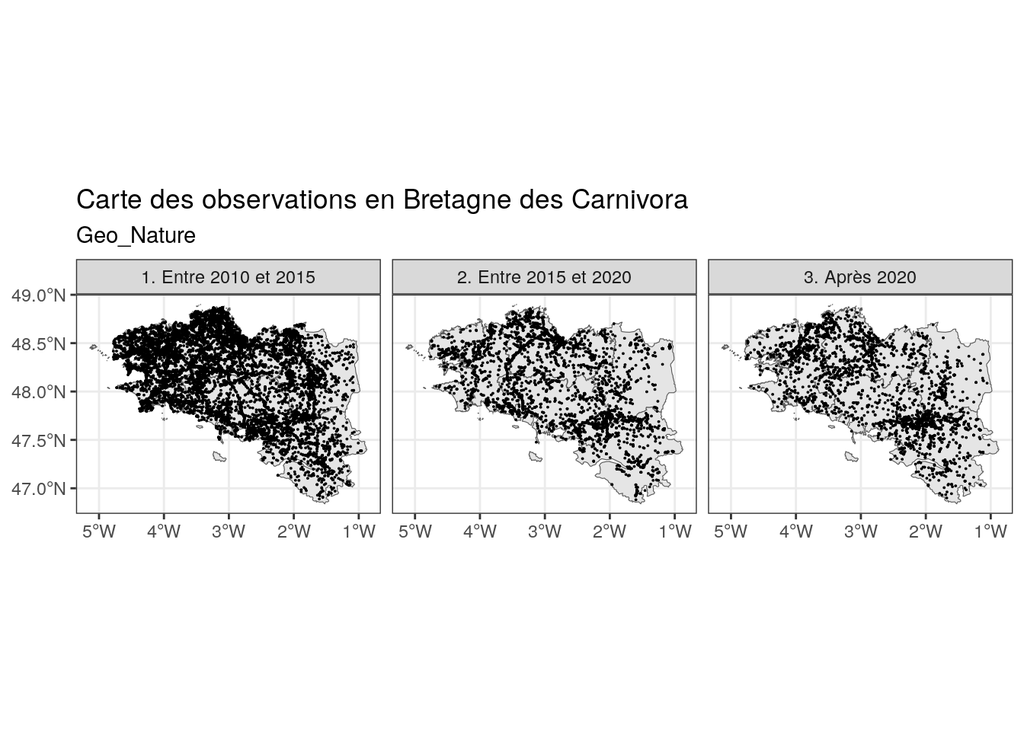

```r
carte_carnivora <- GeoN %>%
  mutate(
    grp_date = case_when(
      date_debut >= as.Date("2010-01-01") & date_debut <= as.Date("2014-12-31") ~ "1. Entre 2010 et 2015",
      date_debut >= as.Date("2015-01-01") & date_debut <= as.Date("2019-12-31") ~ "2. Entre 2015 et 2020",
      date_debut > as.Date("2019-12-31") ~ "3. Après 2020",
      TRUE ~ NA_character_
    )
  ) %>%
  filter(date_debut > as.Date("2010-01-01")) %>%
  dplyr::select(x_centroid_4326,
                y_centroid_4326,
                grp_date,
                ordre,
                date_debut) %>%
  sf::st_as_sf(coords = c("x_centroid_4326", "y_centroid_4326"),
               crs = sf::st_crs(4326))%>%
  filter(ordre == "Carnivora")

ggplot() +
  geom_sf(data = carte_bretagne) +
  labs(title = "Carte des observations en Bretagne des Carnivora",
       subtitle = "Geo_Nature") +
  geom_sf(data = carte_carnivora, size=0.01) +
  theme_bw() + facet_grid(. ~ grp_date)
```

En vrai ca veut pas dire trop grand chose, on savait qu’on voyait en tout moins d’animaux avec les années donc logique ca se réflète ici aussi (Sutout bcp + en T1) On voit quand même un peu de déplacements. A voir plus tard.

Ou alors je prends la BDD avec toutes les données et je selectionne “aléatoirement” 40 000 ou 50 000 données avec les proportions?

Idée 2:

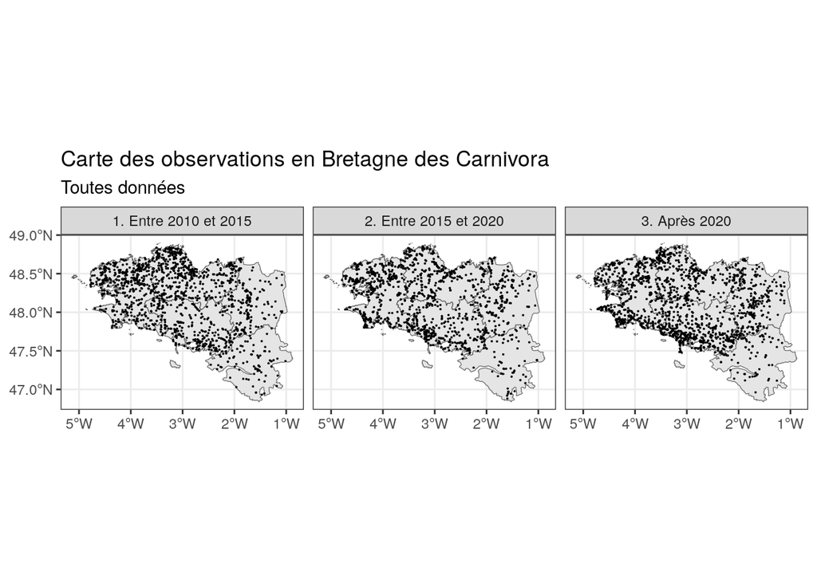

```r
set.seed(12345)

graph_ordre_tranche_annee <- function(ordre_voulu){
  # Creation de la BDD
  ordre_data <- Total_B %>% filter(ordre == ordre_voulu)
  bdd_props <- prop.table(table(ordre_data$bdd))
  n_bdd1 <- round(5000 * bdd_props[1])
  n_bdd2 <- 5000 - n_bdd1
  bdd1 <- ordre_data %>%
    filter(bdd == "GeoN") %>%
    sample_n(min(n_bdd1, n()))
  bdd2 <- ordre_data %>%
    filter(bdd == "VisioN_FB") %>%
    sample_n(min(n_bdd2, n()))

  ordre_graph <- bind_rows(bdd1, bdd2) %>%
    mutate(
      grp_date = case_when(
        date_debut >= as.Date("2010-01-01") & date_debut <= as.Date("2014-12-31") ~ "1. Entre 2010 et 2015",
        date_debut >= as.Date("2015-01-01") & date_debut <= as.Date("2019-12-31") ~ "2. Entre 2015 et 2020",
        date_debut > as.Date("2019-12-31") ~ "3. Après 2020",
        TRUE ~ NA_character_
      )
    ) %>%
    filter(date_debut > as.Date("2010-01-01")) %>%
    sample_frac(1)

  # Transformation pour des données de la carte
  carte_ordre <- ordre_graph %>%
    dplyr::select(x_centroid_4326, y_centroid_4326,
                  grp_date, ordre, date_debut) %>%
    sf::st_as_sf(coords = c("x_centroid_4326", "y_centroid_4326"),
                 crs = sf::st_crs(4326)) %>%
    filter(ordre == ordre_voulu)

  # Plot
  ggplot() +
    geom_sf(data = carte_bretagne) +
    labs(
      title = paste("Carte des observations en Bretagne des", ordre_voulu),
      subtitle = "Toutes données"
    ) +
    geom_sf(data = carte_ordre, size = 0.01) +
    theme_bw() +
    facet_grid(. ~ grp_date)
}

graph_ordre_tranche_annee("Carnivora")
```

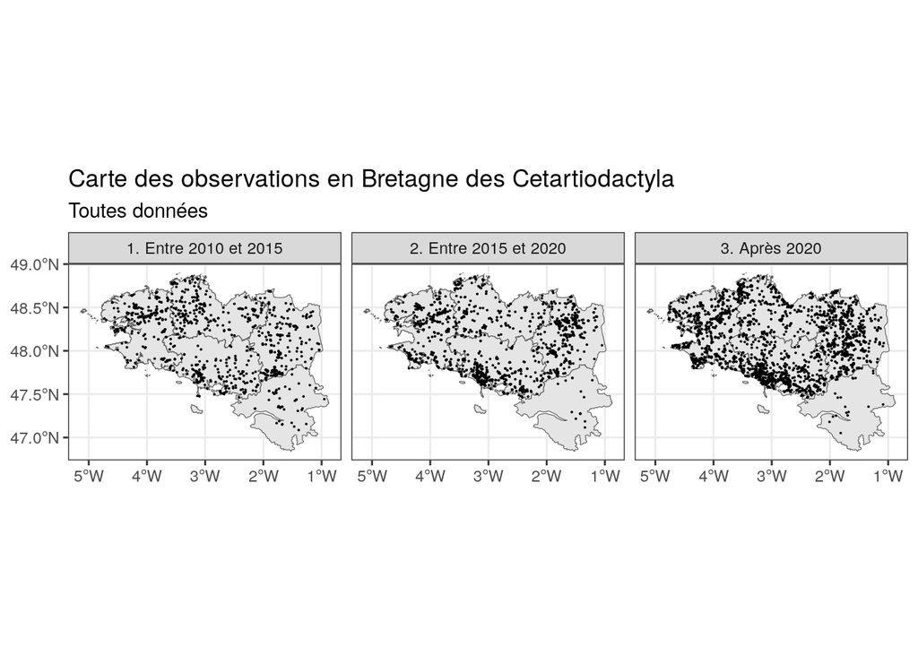

```r
graph_ordre_tranche_annee("Cetartiodactyla")
```

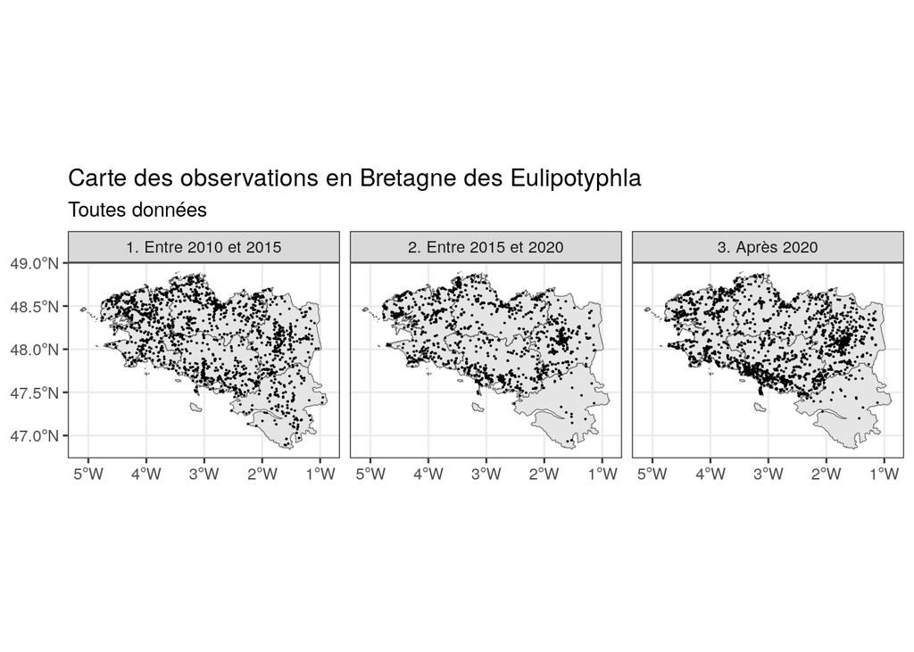

```r
graph_ordre_tranche_annee("Eulipotyphla")
```

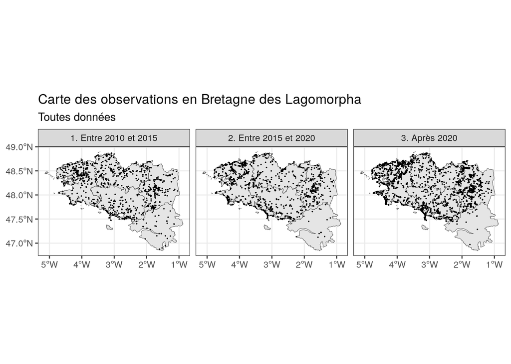

```r
graph_ordre_tranche_annee("Lagomorpha")
```

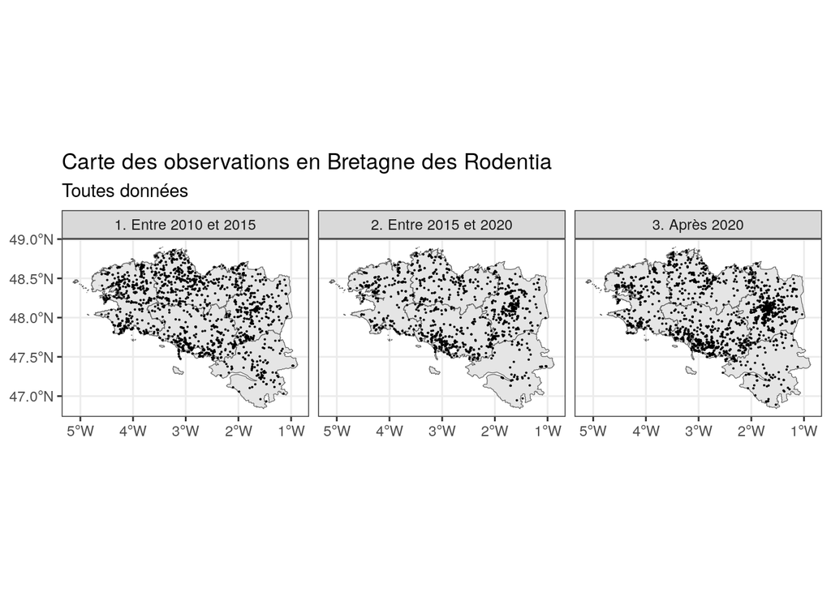

```r
graph_ordre_tranche_annee("Rodentia")
```

## REPARTITION DES ORDRES

Dans la BDD GeoNature, principalement des carnivores, puis relativement uniformement les 4 autres ordres. On se dit que c’est peut être du au fort intéret de GMB pour la loutre, mais pas tant que ca le cas (voir figure de la répartition des ordres sans le loutres.s)

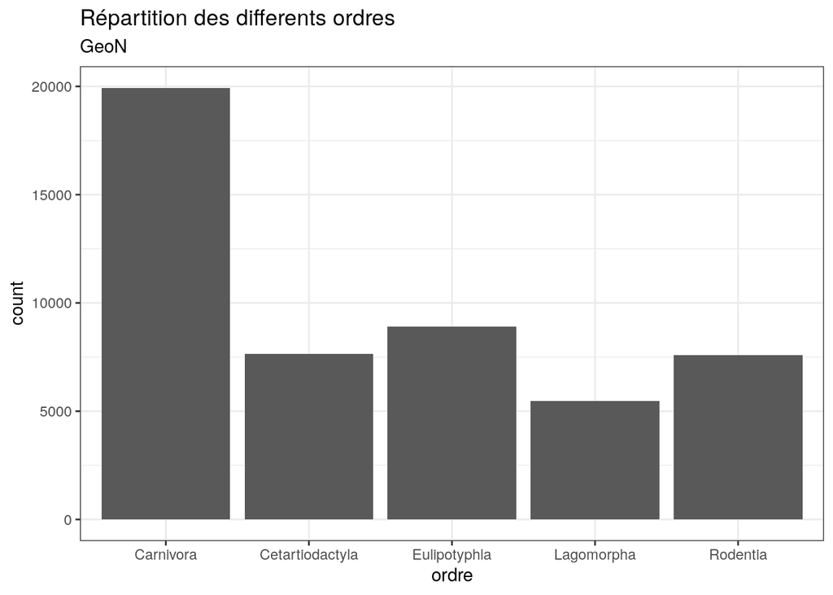

```r
GeoN %>%
  ggplot(aes(ordre))+
  geom_bar()+
  labs(title="Répartition des differents ordres",
       subtitle="GeoN")+
  theme_bw()
```

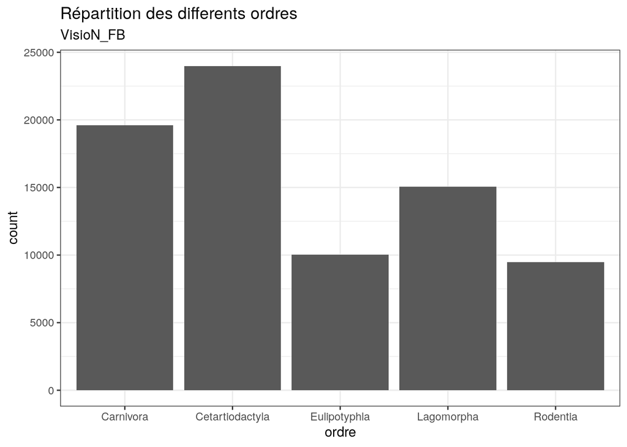

```r
VisioN_FB %>%
  ggplot(aes(ordre))+
  geom_bar()+
  labs(title="Répartition des differents ordres",
       subtitle="VisioN_FB")+
  theme_bw()
```

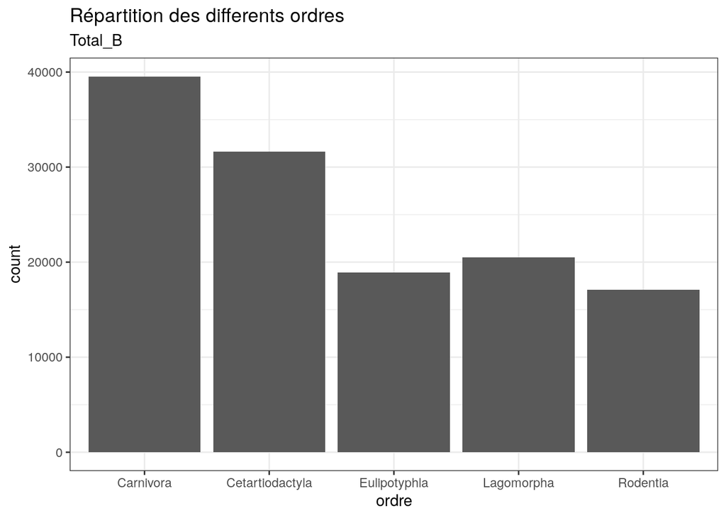

```r
Total_B %>%
  ggplot(aes(ordre))+
  geom_bar()+
  labs(title="Répartition des differents ordres",
       subtitle="Total_B")+
  theme_bw()
```

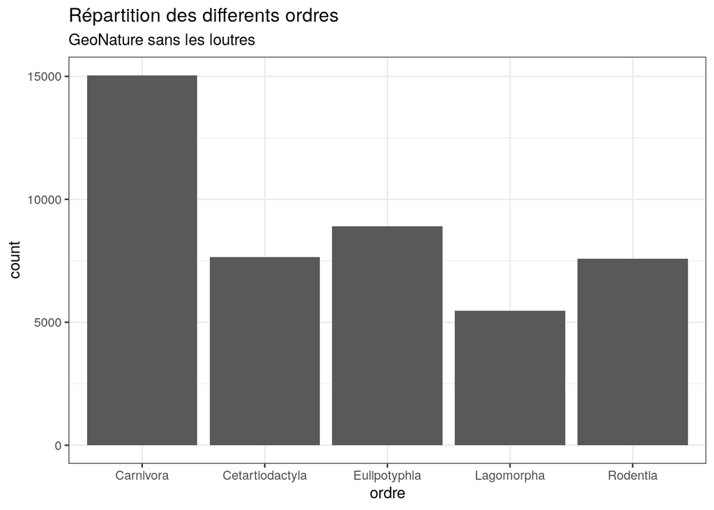

```r
GeoN %>%
  filter(cd_nom != 60630)%>%
  ggplot(aes(ordre))+
  geom_bar()+
  labs(title="Répartition des differents ordres",
       subtitle="GeoNature sans les loutres")+
  theme_bw()
```

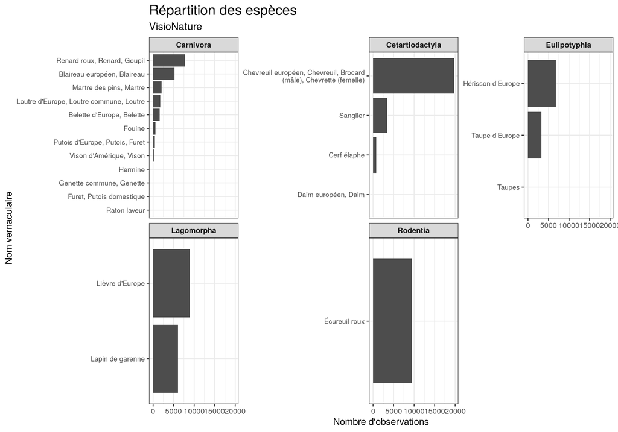

```r
VisioN_FB %>%
  count(nom_vernaculaire, ordre, sort = TRUE) %>%
  ggplot(aes(x = reorder(nom_vernaculaire, n), y = n, fill = ordre)) +
  geom_col(fill = "grey30") +
  coord_flip() +
  facet_wrap(~ ordre, scales = "free_y") +
  labs(
    title = "Répartition des espèces",
    subtitle = "VisioNature",
    y = "Nombre d'observations", x = "Nom vernaculaire"
  ) +
  scale_x_discrete(labels = label_wrap(40)) +
  theme_bw() +
  theme(
    axis.text.y = element_text(size = 8),
    strip.text = element_text(face = "bold"),
    plot.title = element_text(size = 16),
    plot.subtitle = element_text(size = 12)
  )
```

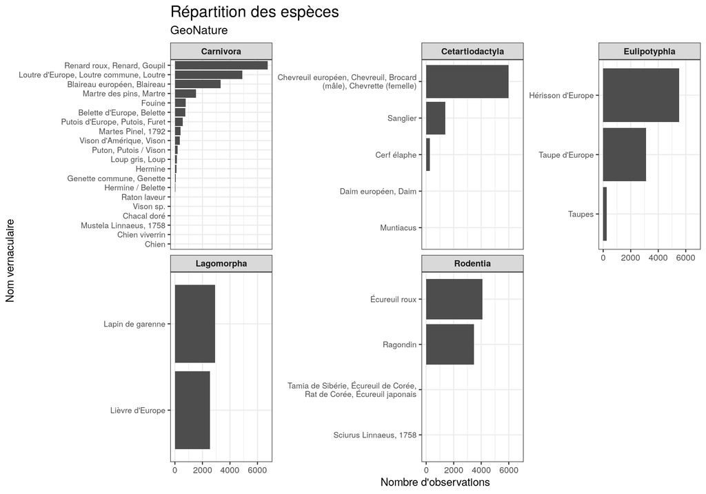

```r
GeoN %>%
  count(nom_vernaculaire, ordre, sort = TRUE) %>%
  ggplot(aes(x = reorder(nom_vernaculaire, n), y = n, fill = ordre)) +
  geom_col(fill = "grey30") +
  coord_flip() +
  facet_wrap(~ ordre, scales = "free_y") +
  labs(
    title = "Répartition des espèces",
    subtitle = "GeoNature",
    y = "Nombre d'observations", x = "Nom vernaculaire"
  ) +
  scale_x_discrete(labels = label_wrap(40)) +
  theme_bw() +
  theme(
    axis.text.y = element_text(size = 8),
    strip.text = element_text(face = "bold"),
    plot.title = element_text(size = 16),
    plot.subtitle = element_text(size = 12)
  )
```

## ETUDE DES PRINCIPAUX OBSERVATEURS

```r
GeoN %>%
  summarize(nb_observateurs = n_distinct(observateurs))
```

```
## # A tibble: 1 × 1
##   nb_observateurs
##             <int>
## 1            2662
```

```r
VisioN_FB %>%
  summarize(nb_observateurs = n_distinct(observateurs))
```

```
## # A tibble: 1 × 1
##   nb_observateurs
##             <int>
## 1            3502
```

On transforme tous les noms en majuscule pour éviter des pb si on regroupe les BDD par la suite.

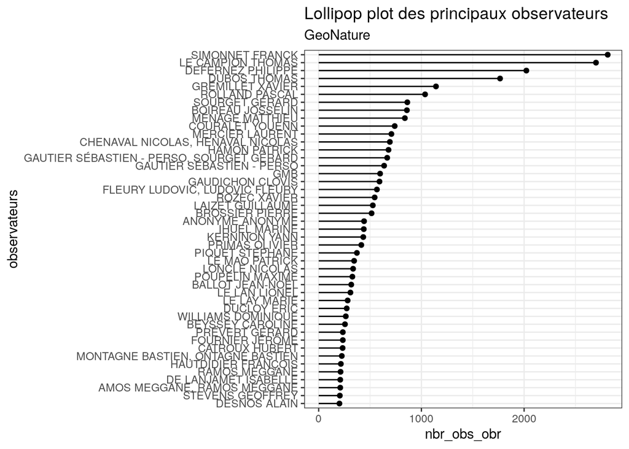

```r
GeoN_summary <- GeoN %>%
  group_by(observateurs) %>%
  summarize(nbr_obs_obr = n()) %>%
  filter(nbr_obs_obr > 200) %>%
  arrange(nbr_obs_obr)

GeoN_summary$observateurs <- factor(GeoN_summary$observateurs,
                                    levels = GeoN_summary$observateurs)

VisioN_summary <- VisioN_FB %>%
  group_by(observateurs) %>%
  summarize(nbr_obs_obr = n()) %>%
  filter(nbr_obs_obr > 400) %>%
  arrange(nbr_obs_obr)

VisioN_summary$observateurs <- factor(VisioN_summary$observateurs,
                                      levels = VisioN_summary$observateurs)
GeoN_summary%>%
  ggplot(aes(x=observateurs, y=nbr_obs_obr)) +
  geom_point() +
  geom_segment( aes(x=observateurs, xend=observateurs,
                    y=0, yend=nbr_obs_obr))+
  coord_flip()+
  labs(title="Lollipop plot des principaux observateurs",
       subtitle="GeoNature")+
  theme_bw()
```

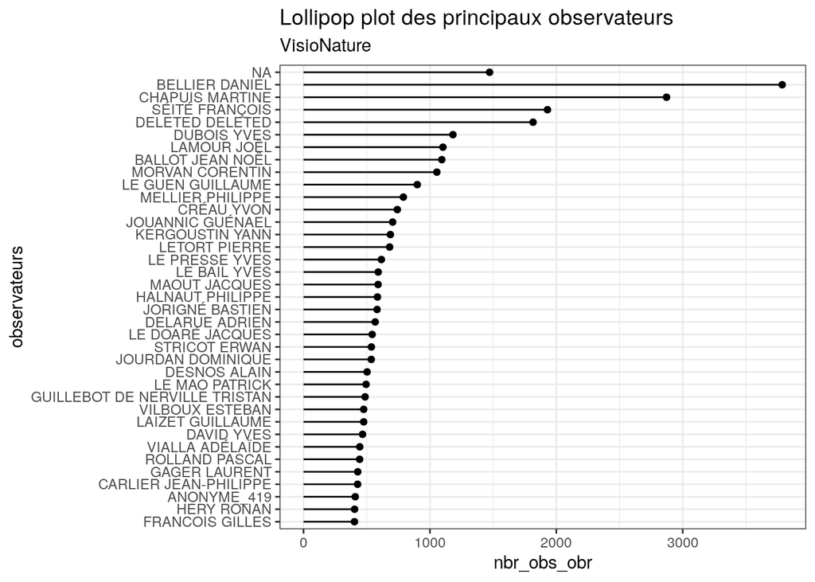

```r
ggplot(VisioN_summary, aes(x=observateurs, y=nbr_obs_obr)) +
  geom_point() +
  geom_segment( aes(x=observateurs, xend=observateurs,
                    y=0, yend=nbr_obs_obr))+
  coord_flip()+
  labs(title="Lollipop plot des principaux observateurs",
       subtitle="VisioNature")+
  theme_bw()
```

Il faudra faire gaffe a pas biaser les résultats car certains participe très grandement au receuil des données donc un changement de leur comportement implique également un changement du comportement de la base de donnée

Regarder les dates des principaux observateurs ainsi que leurs espèces, et les lieux? - des biais pour un endroit du territoire? - des biais pour une espece? - déplacement donc refletement dans les observations? - Arrêt des déclarations pendant un moment?

On se dit peut etre que les gros observateurs sont ceux avec plus de 1500 observations? Faire des fonctions qui permettent d’étudier simplement ces cas.

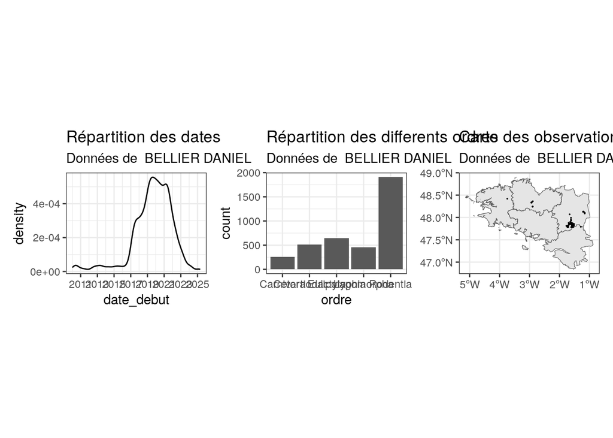

```r
stats_observateur <- function(nom_obs, bdd, carte){

  # Date
  p1 <- bdd %>%
    filter(observateurs == toupper(nom_obs),
           date_debut > as.Date("2010-01-01")) %>%
    ggplot(aes(date_debut))+
    labs(title="Répartition des dates",
         subtitle = paste("Données de ", nom_obs)) +
    theme_bw()+
    geom_line(stat="density")+
    scale_x_date(
    breaks = seq(from = min(bdd$date_debut),
                 to = max(bdd$date_debut),
                 by = "2 years"),
    labels = scales::label_date("%Y")
    )

  # Ordres
  p2 <- bdd %>%
    filter(observateurs == toupper(nom_obs)) %>%
    ggplot(aes(x = ordre)) +
    geom_bar() +
    labs(title = "Répartition des differents ordres",
         subtitle = paste("Données de ", nom_obs)) +
    theme_bw()

  # Carte
  geo_obsteur <- bdd %>%
      filter(date_debut > as.Date("2010-01-01")) %>%
      filter(observateurs == toupper(nom_obs)) %>%
      dplyr::select(x_centroid_4326,
                    y_centroid_4326,
                    ordre,
                    date_debut) %>%
      sf::st_as_sf(coords = c("x_centroid_4326", "y_centroid_4326"),
                   crs = sf::st_crs(4326))
  p3 <- ggplot() +
      geom_sf(data = carte) +
      labs(title = "Carte des observations",
           subtitle = paste("Données de ", nom_obs)) +
      geom_sf(data = geo_obsteur, size=0.01) +
      theme_bw()


  # Affichage des plots
  p1 + p2 + p3
  }

setwd("~/work/AnalyseDonneesOpportunisteGMB/donnees/DepartementsOuest")
carte_bretagne <- st_read("LIM_ADM_DepartementsOuest.shp")
carte_bretagne <- st_set_crs(carte_bretagne, 2154)
carte_bretagne <- st_transform(carte_bretagne, 4326)

stats_observateur(nom_obs="BELLIER DANIEL",
                  bdd=VisioN_FB,
                  carte=carte_bretagne)
```

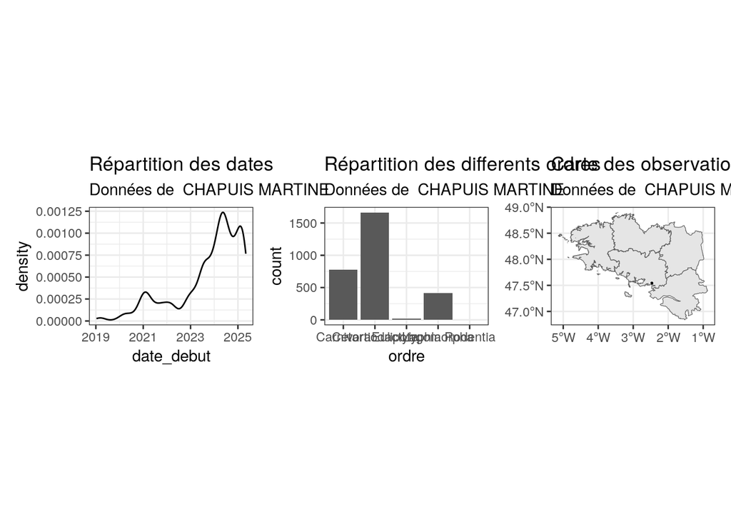

```r
stats_observateur(nom_obs="CHAPUIS MARTINE",
                  bdd=VisioN_FB,
                  carte=carte_bretagne)
```

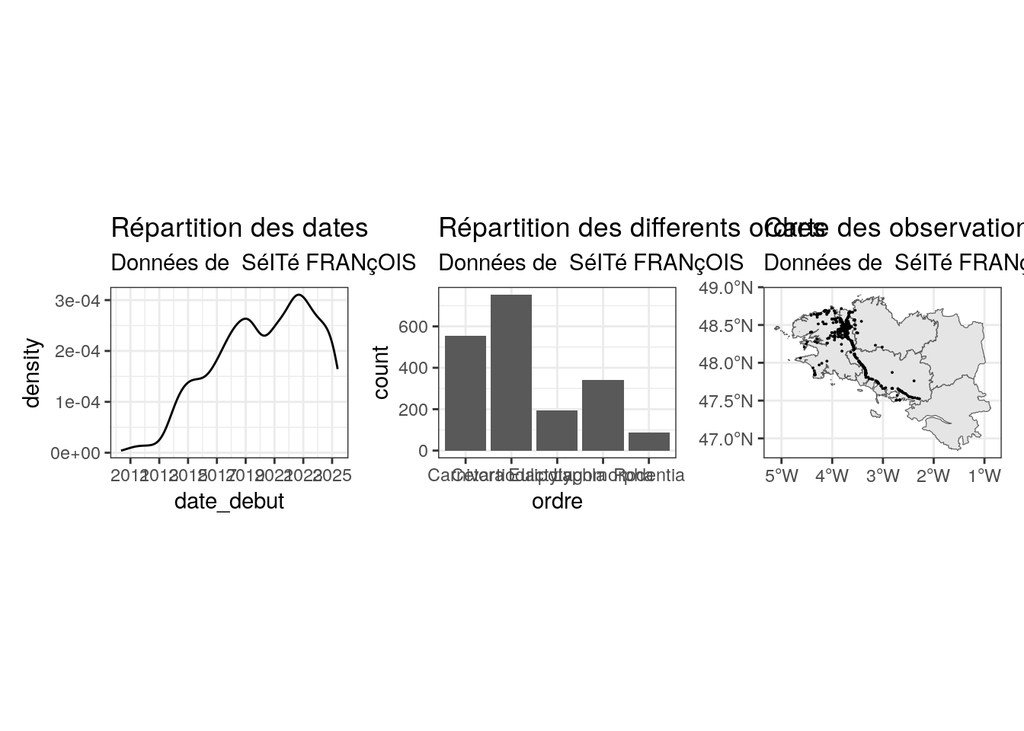

```r
stats_observateur(nom_obs="SéITé FRANçOIS",
                  bdd=VisioN_FB,
                  carte=carte_bretagne)
```